# Borrador

Gustavo A

2026-09-29

# Preparación para cálculos

## Carga de paquetes

```r
paquetes <- c("quantmod", "lubridate")

for (paquete in paquetes) {
  if (!requireNamespace(paquete, quietly = TRUE)) {
    install.packages(paquete, repos = "https://cloud.r-project.org")
  }
}
library(quantmod)
library(lubridate)
```

## Fecha fija y datos de la opción

```r
# Se escoje el lunes,ya que aun aplica lo del dividendo
fecha_valoracion <- as.Date("2026-09-28")
fecha_inicio <- fecha_valoracion %m-% years(5)


opcion <- data.frame(
  contrato = "NTR261218C00072500",
  tipo = "Call",
  vencimiento = as.Date("2026-12-18"),
  strike = 72.50,
  bid = 4.30,
  ask = 4.80,
  ultimo_precio = 4.50
)

opcion$precio_medio <- (opcion$bid + opcion$ask) / 2
opcion$spread <- opcion$ask - opcion$bid

# Precio de cierre regular mostrado en tu captura.
# El 72.20 de poscierre NO se utiliza.
S0 <- 71.98
opcion
```

```
##             contrato tipo vencimiento strike bid ask ultimo_precio precio_medio
## 1 NTR261218C00072500 Call  2026-12-18   72.5 4.3 4.8           4.5         4.55
##   spread
## 1    0.5
```

## Carga de precios históricos de la acción

```r
ntr <- getSymbols(
  "NTR",
  src = "yahoo",
  from = fecha_inicio,
  to = fecha_valoracion + 1,
  auto.assign = FALSE
)

# Aunque Yahoo devolviera más datos posteriores, mantenemos el corte fijado.
ntr <- ntr[as.Date(zoo::index(ntr)) <= fecha_valoracion]

fila_cierre <- ntr[as.character(fecha_valoracion)]


# Guardar los datos usados como respaldo de esta fecha de corte.
historico_ntr <- data.frame(
  fecha = as.Date(zoo::index(ntr)),
  close = as.numeric(Cl(ntr)),
  adjusted = as.numeric(Ad(ntr))
)

write.csv(
  historico_ntr,
  "NTR_historico_20260928.csv",
  row.names = FALSE
)

write.csv(
  opcion,
  "NTR_call_20260928.csv",
  row.names = FALSE
)
```

## Obtener la Tasa libre de riesgo

Para nuestro caso utilizaremos la letra del tesoro a 3 meses

```r
# dtb3 <- getSymbols(
#   "DTB3",
#   src = "FRED",
#   from = fecha_valoracion - 30,
#   to = fecha_valoracion + 1,
#   auto.assign = FALSE
# )
#
# tabla_tasas <- data.frame(
#   fecha = as.Date(zoo::index(dtb3)),
#   tasa_descuento_pct = as.numeric(dtb3[, 1])
# )
#
# tabla_tasas <- tabla_tasas[
#   tabla_tasas$fecha <= fecha_valoracion &
#     is.finite(tabla_tasas$tasa_descuento_pct),
# ]
#
# if (nrow(tabla_tasas) == 0) {
#   stop("No se encontró una tasa DTB3 disponible hasta la fecha de valoración.")
# }
#
# tasa_usada <- tabla_tasas[nrow(tabla_tasas), ]
#
# # DTB3 está en porcentaje anual sobre base de descuento de 360 días.
# # Aproximamos el plazo de la letra de tres meses mediante 91 días.
# dias_letra <- 91
# descuento <- tasa_usada$tasa_descuento_pct / 100
# precio_letra <- 1 - descuento * dias_letra / 360
#
# if (precio_letra <= 0) {
#   stop("La tasa DTB3 produjo un precio de letra inválido.")
# }
#
# # Tasa anual con capitalización continua, en base de 365 días.
# r <- -log(precio_letra) / (dias_letra / 365)
#
# write.csv(
#   tasa_usada,
#   "DTB3_tasa_usada_20260928.csv",
#   row.names = FALSE
# )




# Leer la tasa previamente guardada.
tasa_usada <- read.csv(
  "DTB3_tasa_usada_20260928.csv",
  stringsAsFactors = FALSE
)

tasa_usada$fecha <- as.Date(tasa_usada$fecha)

# Validar la tasa y la fecha de corte.
if (
  nrow(tasa_usada) != 1 ||
  is.na(tasa_usada$fecha) ||
  tasa_usada$fecha > as.Date(fecha_valoracion) ||
  !is.finite(tasa_usada$tasa_descuento_pct)
) {
  stop("El archivo debe contener una tasa válida hasta la fecha de valoración.")
}

# DTB3 está en porcentaje anual sobre base de descuento de 360 días.
# Aproximamos el plazo de la letra de tres meses mediante 91 días.
dias_letra <- 91
descuento <- tasa_usada$tasa_descuento_pct / 100
precio_letra <- 1 - descuento * dias_letra / 360

if (precio_letra <= 0) {
  stop("La tasa DTB3 produjo un precio de letra inválido.")
}

# Tasa anual con capitalización continua, en base de 365 días.
r <- -log(precio_letra) / (dias_letra / 365)
r_cobertura  <- -log(precio_letra) / (dias_letra / 365)
```

## Cálculo de volatidad histórica

Para uso de la valoración siendo el sigma

```r
precios_ajustados <- historico_ntr$adjusted
precios_ajustados <- precios_ajustados[
  is.finite(precios_ajustados) & precios_ajustados > 0
]

if (length(precios_ajustados) < 253) {
  stop("Se necesitan al menos 253 precios para obtener 252 rendimientos.")
}

rendimientos <- tail(diff(log(precios_ajustados)), 252)
sigma <- sd(rendimientos) * sqrt(252)
sigma
```

```
## [1] 0.3366046
```

##Tiempo hasta el vencimiento

```r
dias_vencimiento <- as.numeric(
  opcion$vencimiento - fecha_valoracion
)

plazo_anios <- dias_vencimiento / 365

if (plazo_anios <= 0 || sigma <= 0) {
  stop("El plazo y la volatilidad deben ser positivos.")
}
plazo_anios
```

```
## [1] 0.2219178
```

# (a) Los tres caminos.

## Aparato

### Fórmula cerrada de Black-Scholes

Para valorar la opción se utiliza la fórmula cerrada de Black-Scholes presentada en **Björk, Proposición 7.13 (Black-Scholes Formula)**. Para una opción call europea con precio de ejercicio $K$ y vencimiento $T$, su valor en el instante $t$ está dado por:

$$C(t,S_t)
=
S_tN(d_1)
-
Ke^{-r(T-t)}N(d_2),$$

donde

$$d_1
=
\frac{
\ln(S_t/K)
+
\left(r+\frac{1}{2}\sigma^2\right)(T-t)
}{
\sigma\sqrt{T-t}
},$$

$$d_2=d_1-\sigma\sqrt{T-t}.$$

Aquí, $N(\cdot)$ representa la función de distribución acumulada de una normal estándar.

Para aplicar la Proposición 7.13 se supone que la opción se trata como **europea y sin dividendos**, que la tasa libre de riesgo $r$ y la volatilidad $\sigma$ son constantes durante la vida de la opción, y que el precio del activo sigue la dinámica de Black-Scholes.

```r
precio_bs_call <- function(S, K, r, sigma, plazo) {
  d1 <- (
    log(S / K) + (r + sigma^2 / 2) * plazo
  ) / (sigma * sqrt(plazo))

  d2 <- d1 - sigma * sqrt(plazo)

  S * pnorm(d1) - K * exp(-r * plazo) * pnorm(d2)
}

precio_bs_bjork <- precio_bs_call(
  S = S0,
  K = opcion$strike,
  r = r,
  sigma = sigma,
  plazo = plazo_anios
)
print(r)
```

```
## [1] 0.04178635
```

```r
print(q)
```

[output not shown]

```r
precio_bs_bjork
```

```
## [1] 4.618929
```

## Capa de verificación

Se realizaron chequeos sobre el resultado obtenido mediante la fórmula cerrada. Se verificó que el precio calculado fuera finito y que cumpliera las cotas de no arbitraje para una call europea:

$$\max(S_0-Ke^{-rT},0)\leq C_0\leq S_0.$$

```r
limite_inferior <- max(S0 - opcion$strike * exp(-r * plazo_anios), 0)
limite_superior <- S0

chequeos <- data.frame(
  Chequeo = c(
    "Precio finito",
    "Cota inferior de no arbitraje",
    "Cota superior de no arbitraje",
    "Precio dentro del bid-ask"
  ),
  Resultado = c(
    is.finite(precio_bs_bjork),
    precio_bs_bjork >= limite_inferior,
    precio_bs_bjork <= limite_superior,
    precio_bs_bjork >= opcion$bid & precio_bs_bjork <= opcion$ask
  )
)

chequeos
```

```
##                         Chequeo Resultado
## 1                 Precio finito      TRUE
## 2 Cota inferior de no arbitraje      TRUE
## 3 Cota superior de no arbitraje      TRUE
## 4     Precio dentro del bid-ask      TRUE
```

## El supuesto que no se cumplió

El supuesto de ausencia de dividendos no se sostiene para este caso concreto porque NTR tiene un dividendo de $0.55 cuya fecha ex-dividendo es el 29/09/2026, dentro de la vida de la opción.

Para incorporar el dividendo conocido en el modelo de Black-Scholes, se calcula primero su valor presente:

$$PV(D)=\sum_{i=1}^{n}D_i e^{-rt_i}$$

Luego, se obtiene un *dividend yield* continuo equivalente $q$, definido mediante:

$$S_0e^{-qT}=S_0-PV(D)$$

Despejando $q$:

$$q=-\frac{1}{T}\ln\left(\frac{S_0-PV(D)}{S_0}\right)$$

Para la opción seleccionada se tiene $S_0=71.98$ y un dividendo de $0.55$ USD por acción, con fecha ex-dividendo el 29 de septiembre de 2026. El valor de $q$ obtenido se utiliza posteriormente en la valoración mediante Black-Scholes.

```r
# Dividend yield continuo equivalente

dividendos <- data.frame(
  fecha_exdividendo = as.Date("2026-09-29"),
  monto_por_accion = 0.55
)

dividendos <- dividendos[
  dividendos$fecha_exdividendo > fecha_valoracion &
    dividendos$fecha_exdividendo <= opcion$vencimiento,
  ,
  drop = FALSE
]

tiempo_dividendos <- as.numeric(
  dividendos$fecha_exdividendo - fecha_valoracion
) / 365

vp_dividendos <- sum(
  dividendos$monto_por_accion * exp(-r * tiempo_dividendos)
)

q <- -(1 / plazo_anios) * log(
  (S0 - vp_dividendos) / S0
)

cat("Valor presente de dividendos:", vp_dividendos, "\n") #Casi el mismo porque solo vive un día
```

```
## Valor presente de dividendos: 0.549937
```

```r
cat("Dividend yield continuo (q):", q, "\n")
```

```
## Dividend yield continuo (q): 0.03455997
```

```r
# Black-Scholes con dividend yield continuo

precio_bs_call_div <- function(S, K, r, q, sigma, plazo) {

  d1 <- (
    log(S / K) + (r - q + sigma^2 / 2) * plazo
  ) / (sigma * sqrt(plazo))

  d2 <- d1 - sigma * sqrt(plazo)

  S * exp(-q * plazo) * pnorm(d1) -
    K * exp(-r * plazo) * pnorm(d2)
}


precio_bs_div <- precio_bs_call_div(
  S = S0,
  K = opcion$strike,
  r = r,
  q = q,
  sigma = sigma,
  plazo = plazo_anios
)

precio_bs_div
```

```
## [1] 4.329007
```

Al considerar el dividendo reduce el valor estimado de la call en aproximadamente $0.29. No obstante, el precio corregido continúa dentro del intervalo bid-ask observado, $[4.30,4.80]$.

## Aparato

### La EDP de Black-Scholes resuelta hacia atrás

Como segundo método de valoración se utiliza la ecuación diferencial parcial de Black-Scholes presentada en **Björk, Teorema 7.10**. Para una opción europea cuyo valor se denota por $V(t,S)$, la EDP sin dividendos es

$$\frac{\partial V}{\partial t}
+
rS\frac{\partial V}{\partial S}
+
\frac{1}{2}\sigma^2S^2
\frac{\partial^2V}{\partial S^2}
-rV
=
0.$$

Para una opción call europea, la condición terminal al vencimiento es

$$V(T,S)=\max(S-K,0).$$

A diferencia de la fórmula cerrada de Black-Scholes, en este método el precio de la opción se obtiene resolviendo la EDP **hacia atrás**, partiendo del payoff conocido al vencimiento $T$ y retrocediendo hasta el instante de valoración.

Para obtener una solución numérica se utiliza el método de diferencias finitas de **Crank-Nicolson**. Se construye una malla para el precio del activo y para el tiempo:

$$S_i=i\Delta S,$$

$$t_n=n\Delta t,$$

donde

$$\Delta S=\frac{S_{\max}}{M},$$

y

$$\Delta t=\frac{T}{N}.$$

Crank-Nicolson utiliza un promedio de las aproximaciones de la EDP en dos niveles temporales consecutivos. En cada paso se obtiene un sistema lineal tridiagonal, el cual se resuelve para encontrar el valor de la opción en el instante inmediatamente anterior.

```r
pde_price <- function(S, K, r, sigma, Tt,
                      q = 0,
                      type = c("call", "put"),
                      Smax_mult = 4,
                      M = 200,
                      N = 2000) {

  type <- match.arg(type)

  if (any(!is.finite(c(S, K, r, sigma, Tt, q, Smax_mult))) ||
      S <= 0 || K <= 0 || sigma <= 0 || Tt < 0) {
    stop("Revise S, K, r, sigma, Tt y q.")
  }

  if (Tt == 0) {
    return(
      if (type == "call") {
        max(S - K, 0)
      } else {
        max(K - S, 0)
      }
    )
  }

  if (M < 3 || N < 1 ||
      M != as.integer(M) ||
      N != as.integer(N) ||
      Smax_mult <= 1) {
    stop("Se requiere M >= 3, N >= 1 y Smax_mult > 1.")
  }


  # Resuelve un sistema tridiagonal mediante el algoritmo de Thomas

  resolver_tridiagonal <- function(inferior, diagonal, superior, rhs) {

    n <- length(diagonal)

    c_mod <- numeric(n - 1)
    d_mod <- numeric(n)

    c_mod[1] <- superior[1] / diagonal[1]
    d_mod[1] <- rhs[1] / diagonal[1]

    for (j in 2:n) {

      pivote <- diagonal[j] -
        inferior[j - 1] * c_mod[j - 1]

      if (!is.finite(pivote) || abs(pivote) < 1e-14) {
        stop("El sistema numerico tiene un pivote invalido.")
      }

      if (j < n) {
        c_mod[j] <- superior[j] / pivote
      }

      d_mod[j] <- (
        rhs[j] -
          inferior[j - 1] * d_mod[j - 1]
      ) / pivote
    }

    x <- numeric(n)
    x[n] <- d_mod[n]

    for (j in (n - 1):1) {
      x[j] <- d_mod[j] - c_mod[j] * x[j + 1]
    }

    x
  }


  # Construccion de la malla

  Smax <- Smax_mult * max(S, K)
  dS <- Smax / M
  dt <- Tt / N

  Svec <- (0:M) * dS


  # Condicion terminal:
  # valor de la opcion al vencimiento

  V <- if (type == "call") {
    pmax(Svec - K, 0)
  } else {
    pmax(K - Svec, 0)
  }


  # Nodos interiores

  i <- 1:(M - 1)


  # Coeficientes de Crank-Nicolson

  a <- 0.25 * dt *
    (sigma^2 * i^2 - (r - q) * i)

  b <- -0.5 * dt *
    (sigma^2 * i^2 + r)

  c <- 0.25 * dt *
    (sigma^2 * i^2 + (r - q) * i)


  m <- M - 1

  inferior <- -a[2:m]
  diagonal <- 1 - b
  superior <- -c[1:(m - 1)]


  # Se parte del payoff en T y se retrocede
  # hasta obtener el valor de la opcion hoy

  for (paso in 1:N) {

    tau_nuevo <- paso * dt


    # Condiciones de frontera

    if (type == "call") {

      borde_izq <- 0

      borde_der <- Smax * exp(-q * tau_nuevo) -
        K * exp(-r * tau_nuevo)

    } else {

      borde_izq <- K * exp(-r * tau_nuevo)
      borde_der <- 0
    }


    interior <- V[2:M]


    # Lado derecho del sistema de Crank-Nicolson

    rhs <- (1 + b) * interior

    rhs[2:m] <- rhs[2:m] +
      a[2:m] * interior[1:(m - 1)]

    rhs[1:(m - 1)] <- rhs[1:(m - 1)] +
      c[1:(m - 1)] * interior[2:m]


    # Incorporacion de condiciones de frontera

    rhs[1] <- rhs[1] +
      a[1] * (V[1] + borde_izq)

    rhs[m] <- rhs[m] +
      c[m] * (V[M + 1] + borde_der)


    # Resolucion del sistema tridiagonal

    V[2:M] <- resolver_tridiagonal(
      inferior,
      diagonal,
      superior,
      rhs
    )


    V[1] <- borde_izq
    V[M + 1] <- borde_der
  }


  # Interpolacion en el precio observado S

  approx(
    x = Svec,
    y = V,
    xout = S
  )$y
}
```

Primero se valora la opción manteniendo el supuesto de ausencia de dividendos, es decir, tomando $q=0$.

```r
precio_edp_bjork <- pde_price(
  S = S0,
  K = opcion$strike,
  r = r,
  sigma = sigma,
  Tt = plazo_anios,
  q = 0,
  type = "call",
  Smax_mult = 4,
  M = 200,
  N = 2000
)

precio_edp_bjork
```

```
## [1] 4.618335
```

## Capa de verificación

Como primera verificación se comprueba que el precio obtenido sea finito y que satisfaga las cotas de no arbitraje para una call europea sin dividendos:

$$\max(S_0-Ke^{-rT},0)
\leq C_0
\leq S_0.$$

Además, dado que la fórmula cerrada de Black-Scholes y la EDP resuelven el mismo problema bajo los mismos supuestos, se compara el resultado de ambos métodos.

```r
limite_inferior_edp <- max(
  S0 - opcion$strike * exp(-r * plazo_anios),
  0
)

limite_superior_edp <- S0

diferencia_edp_bs <- abs(
  precio_edp_bjork - precio_bs_bjork
)

chequeos_edp <- data.frame(
  Chequeo = c(
    "Precio finito",
    "Cota inferior de no arbitraje",
    "Cota superior de no arbitraje",
    "Cercania con Black-Scholes",
    "Precio dentro del bid-ask"
  ),
  Resultado = c(
    is.finite(precio_edp_bjork),
    precio_edp_bjork >= limite_inferior_edp,
    precio_edp_bjork <= limite_superior_edp,
    diferencia_edp_bs < 0.05,
    precio_edp_bjork >= opcion$bid &
      precio_edp_bjork <= opcion$ask
  )
)

chequeos_edp
```

```
##                         Chequeo Resultado
## 1                 Precio finito      TRUE
## 2 Cota inferior de no arbitraje      TRUE
## 3 Cota superior de no arbitraje      TRUE
## 4    Cercania con Black-Scholes      TRUE
## 5     Precio dentro del bid-ask      TRUE
```

```r
cat(
  "Diferencia absoluta EDP vs Black-Scholes:",
  diferencia_edp_bs,
  "\n"
)
```

```
## Diferencia absoluta EDP vs Black-Scholes: 0.0005940858
```

También se realiza una comprobación de estabilidad numérica aumentando el número de intervalos espaciales y temporales. Si el resultado cambia poco al refinar la malla, esto indica que la discretización utilizada es suficientemente fina.

```r
precio_edp_fino <- pde_price(
  S = S0,
  K = opcion$strike,
  r = r,
  sigma = sigma,
  Tt = plazo_anios,
  q = 0,
  type = "call",
  Smax_mult = 4,
  M = 400,
  N = 4000
)

cat(
  "EDP M = 200, N = 2000:",
  precio_edp_bjork,
  "\n"
)
```

```
## EDP M = 200, N = 2000: 4.618335
```

```r
cat(
  "EDP M = 400, N = 4000:",
  precio_edp_fino,
  "\n"
)
```

```
## EDP M = 400, N = 4000: 4.618521
```

```r
cat(
  "Diferencia por refinamiento:",
  abs(precio_edp_bjork - precio_edp_fino),
  "\n"
)
```

```
## Diferencia por refinamiento: 0.0001862473
```

## El supuesto que no se cumplió

La primera valoración mediante la EDP supone, al igual que la fórmula cerrada de Black-Scholes utilizada anteriormente, que el activo no paga dividendos.

Sin embargo, NTR tiene un dividendo de $0.55 con fecha ex-dividendo dentro de la vida de la opción. Para mantener la misma formulación utilizada en los tres métodos se emplea el rendimiento continuo equivalente $q$ calculado anteriormente.

Con dividendos, la EDP se modifica a

$$\frac{\partial V}{\partial t}
+
(r-q)S\frac{\partial V}{\partial S}
+
\frac{1}{2}\sigma^2S^2
\frac{\partial^2V}{\partial S^2}
-rV
=
0.$$

Por tanto, la principal modificación consiste en que el término

$$rS\frac{\partial V}{\partial S}$$

pasa a ser

$$(r-q)S\frac{\partial V}{\partial S}.$$

Para una call, también se modifica la condición de frontera cuando el precio del activo es suficientemente grande. Sin dividendos se utiliza

$$S-Ke^{-r(T-t)},$$

mientras que con dividendos se emplea

$$Se^{-q(T-t)}
-
Ke^{-r(T-t)}.$$

```r
precio_edp_div <- pde_price(
  S = S0,
  K = opcion$strike,
  r = r,
  sigma = sigma,
  Tt = plazo_anios,
  q = q,
  type = "call",
  Smax_mult = 4,
  M = 200,
  N = 2000
)

precio_edp_div
```

```
## [1] 4.328428
```

```r
cat(
  "EDP sin dividendos:",
  precio_edp_bjork,
  "\n"
)
```

```
## EDP sin dividendos: 4.618335
```

```r
cat(
  "EDP con dividendos:",
  precio_edp_div,
  "\n"
)
```

```
## EDP con dividendos: 4.328428
```

```r
cat(
  "Cambio por dividendos:",
  precio_edp_div - precio_edp_bjork,
  "\n"
)
```

```
## Cambio por dividendos: -0.2899071
```

Para una call europea con rendimiento continuo por dividendos, las cotas de no arbitraje utilizadas son

$$\max
\left(
S_0e^{-qT}-Ke^{-rT},
0
\right)
\leq C_0
\leq
S_0e^{-qT}.$$

```r
limite_inferior_edp_div <- max(
  S0 * exp(-q * plazo_anios) -
    opcion$strike * exp(-r * plazo_anios),
  0
)

limite_superior_edp_div <- S0 * exp(-q * plazo_anios)

chequeos_edp_div <- data.frame(
  Chequeo = c(
    "Precio finito",
    "Cota inferior con dividendos",
    "Cota superior con dividendos",
    "Precio dentro del bid-ask"
  ),
  Resultado = c(
    is.finite(precio_edp_div),
    precio_edp_div >= limite_inferior_edp_div,
    precio_edp_div <= limite_superior_edp_div,
    precio_edp_div >= opcion$bid &
      precio_edp_div <= opcion$ask
  )
)

chequeos_edp_div
```

```
##                        Chequeo Resultado
## 1                Precio finito      TRUE
## 2 Cota inferior con dividendos      TRUE
## 3 Cota superior con dividendos      TRUE
## 4    Precio dentro del bid-ask      TRUE
```

La incorporación del dividendo no modifica el método numérico utilizado. La EDP continúa resolviéndose mediante Crank-Nicolson; lo que cambia es la ecuación que se resuelve al incorporar el rendimiento por dividendos $q$.

## Aparato

### Monte Carlo bajo $Q$

Como tercer método se utiliza la representación neutral al riesgo de **Björk, Teorema 7.11**. Bajo la medida neutral al riesgo $Q$, el valor de una opción europea puede expresarse como el valor esperado descontado de su payoff:

$$V_0
=
E^Q
\left[
e^{-rT}\Phi(S_T)
\right].$$

Para una opción call europea,

$$\Phi(S_T)=\max(S_T-K,0),$$

por lo que

$$C_0
=
e^{-rT}
E^Q
\left[
\max(S_T-K,0)
\right].$$

Sin dividendos, bajo la medida neutral al riesgo el precio terminal del activo se modela mediante

$$S_T
=
S_0
\exp
\left[
\left(
r-\frac{1}{2}\sigma^2
\right)T
+
\sigma\sqrt{T}Z
\right],$$

donde

$$Z\sim N(0,1).$$

El estimador Monte Carlo del precio de la opción es entonces

$$\widehat C_0
=
\frac{1}{n}
\sum_{j=1}^{n}
e^{-rT}
\max
\left(
S_T^{(j)}-K,
0
\right).$$

```r
mc_price <- function(S, K, r, sigma, Tt,
                     q = 0,
                     type = c("call", "put"),
                     nsim = 200000,
                     seed = 20260924) {

  type <- match.arg(type)

  set.seed(seed)

  Z <- rnorm(nsim)

  ST <- S * exp(
    (r - q - 0.5 * sigma^2) * Tt +
      sigma * sqrt(Tt) * Z
  )

  payoff <- if (type == "call") {
    pmax(ST - K, 0)
  } else {
    pmax(K - ST, 0)
  }

  payoff_desc <- exp(-r * Tt) * payoff

  precio <- mean(payoff_desc)

  se <- sd(payoff_desc) / sqrt(nsim)

  ic95 <- precio + c(-1, 1) * 1.96 * se

  list(
    precio = precio,
    se = se,
    ic95 = ic95
  )
}
```

La primera estimación se realiza nuevamente bajo el supuesto de ausencia de dividendos.

```r
resultado_mc_bjork <- mc_price(
  S = S0,
  K = opcion$strike,
  r = r,
  sigma = sigma,
  Tt = plazo_anios,
  q = 0,
  type = "call",
  nsim = 200000,
  seed = 20260924
)

precio_mc_bjork <- resultado_mc_bjork$precio

resultado_mc_bjork
```

```
## $precio
## [1] 4.634759
##
## $se
## [1] 0.01648811
##
## $ic95
## [1] 4.602442 4.667075
```

Debido a que Monte Carlo utiliza una cantidad finita de simulaciones, el resultado presenta error de muestreo.

El error estándar se calcula mediante

$$SE
=
\frac{s}{\sqrt{n}},$$

donde $s$ es la desviación estándar de los payoffs descontados.

A partir de este error estándar se construye un intervalo de confianza aproximado del 95%:

$$\widehat C_0
\pm
1.96SE.$$

## Capa de verificación

Se verifica que el precio estimado sea finito, que el error estándar sea positivo y que el valor obtenido respete las cotas de no arbitraje.

Además, se comprueba si el valor de Black-Scholes se encuentra dentro del intervalo de confianza del 95% obtenido mediante Monte Carlo. Debido a que ambos procedimientos están valorando la misma opción bajo el mismo modelo, sus resultados deberían ser consistentes salvo por el error de simulación.

```r
chequeos_mc <- data.frame(
  Chequeo = c(
    "Precio finito",
    "Error estandar finito",
    "Error estandar positivo",
    "Cota inferior de no arbitraje",
    "Cota superior de no arbitraje",
    "Black-Scholes dentro del IC 95%",
    "Precio MC dentro del bid-ask"
  ),
  Resultado = c(
    is.finite(resultado_mc_bjork$precio),
    is.finite(resultado_mc_bjork$se),
    resultado_mc_bjork$se > 0,
    resultado_mc_bjork$precio >= limite_inferior_edp,
    resultado_mc_bjork$precio <= limite_superior_edp,
    precio_bs_bjork >= resultado_mc_bjork$ic95[1] &
      precio_bs_bjork <= resultado_mc_bjork$ic95[2],
    resultado_mc_bjork$precio >= opcion$bid &
      resultado_mc_bjork$precio <= opcion$ask
  )
)

chequeos_mc
```

```
##                           Chequeo Resultado
## 1                   Precio finito      TRUE
## 2           Error estandar finito      TRUE
## 3         Error estandar positivo      TRUE
## 4   Cota inferior de no arbitraje      TRUE
## 5   Cota superior de no arbitraje      TRUE
## 6 Black-Scholes dentro del IC 95%      TRUE
## 7    Precio MC dentro del bid-ask      TRUE
```

```r
cat(
  "Precio Monte Carlo:",
  resultado_mc_bjork$precio,
  "\n"
)
```

```
## Precio Monte Carlo: 4.634759
```

```r
cat(
  "Error estandar:",
  resultado_mc_bjork$se,
  "\n"
)
```

```
## Error estandar: 0.01648811
```

```r
cat(
  "IC 95%:",
  resultado_mc_bjork$ic95[1],
  resultado_mc_bjork$ic95[2],
  "\n"
)
```

```
## IC 95%: 4.602442 4.667075
```

Como comprobación adicional se aumenta el número de simulaciones. El error estándar de Monte Carlo debería disminuir aproximadamente en proporción a

$$\frac{1}{\sqrt{n}}.$$

```r
resultado_mc_grande <- mc_price(
  S = S0,
  K = opcion$strike,
  r = r,
  sigma = sigma,
  Tt = plazo_anios,
  q = 0,
  type = "call",
  nsim = 500000,
  seed = 20260924
)

cat(
  "SE con 200000 simulaciones:",
  resultado_mc_bjork$se,
  "\n"
)
```

```
## SE con 200000 simulaciones: 0.01648811
```

```r
cat(
  "SE con 500000 simulaciones:",
  resultado_mc_grande$se,
  "\n"
)
```

```
## SE con 500000 simulaciones: 0.01042539
```

## El supuesto que no se cumplió

La simulación anterior supone que NTR no paga dividendos. Bajo ese supuesto, la deriva del activo bajo la medida neutral al riesgo es $r$.

Al incorporar un rendimiento continuo por dividendos $q$, la dinámica bajo $Q$ pasa a ser

$$dS_t
=
(r-q)S_t\,dt
+
\sigma S_t\,dW_t^Q.$$

Por tanto, el precio terminal simulado pasa de

$$S_T
=
S_0
\exp
\left[
\left(
r-\frac{\sigma^2}{2}
\right)T
+
\sigma\sqrt{T}Z
\right]$$

a

$$S_T
=
S_0
\exp
\left[
\left(
r-q-\frac{\sigma^2}{2}
\right)T
+
\sigma\sqrt{T}Z
\right].$$

El factor utilizado para descontar el payoff no cambia. El precio continúa calculándose mediante

$$C_0
=
e^{-rT}
E^Q
\left[
\max(S_T-K,0)
\right].$$

Por lo tanto, $q$ modifica la evolución del activo bajo la medida neutral al riesgo, mientras que $r$ continúa siendo la tasa utilizada para descontar el payoff.

```r
resultado_mc_div <- mc_price(
  S = S0,
  K = opcion$strike,
  r = r,
  sigma = sigma,
  Tt = plazo_anios,
  q = q,
  type = "call",
  nsim = 200000,
  seed = 20260924
)

precio_mc_div <- resultado_mc_div$precio

resultado_mc_div
```

```
## $precio
## [1] 4.344091
##
## $se
## [1] 0.01595613
##
## $ic95
## [1] 4.312817 4.375365
```

```r
cat(
  "Monte Carlo sin dividendos:",
  precio_mc_bjork,
  "\n"
)
```

```
## Monte Carlo sin dividendos: 4.634759
```

```r
cat(
  "Monte Carlo con dividendos:",
  precio_mc_div,
  "\n"
)
```

```
## Monte Carlo con dividendos: 4.344091
```

```r
cat(
  "Cambio por dividendos:",
  precio_mc_div - precio_mc_bjork,
  "\n"
)
```

```
## Cambio por dividendos: -0.2906673
```

Se comprueba nuevamente que el precio con dividendos satisfaga las cotas de no arbitraje correspondientes y que el resultado de Black-Scholes con dividendos se encuentre dentro del intervalo de confianza de Monte Carlo.

```r
chequeos_mc_div <- data.frame(
  Chequeo = c(
    "Precio finito",
    "Error estandar finito",
    "Error estandar positivo",
    "Cota inferior con dividendos",
    "Cota superior con dividendos",
    "Black-Scholes con dividendos dentro del IC 95%",
    "Precio MC dentro del bid-ask"
  ),
  Resultado = c(
    is.finite(resultado_mc_div$precio),
    is.finite(resultado_mc_div$se),
    resultado_mc_div$se > 0,
    resultado_mc_div$precio >= limite_inferior_edp_div,
    resultado_mc_div$precio <= limite_superior_edp_div,
    precio_bs_div >= resultado_mc_div$ic95[1] &
      precio_bs_div <= resultado_mc_div$ic95[2],
    resultado_mc_div$precio >= opcion$bid &
      resultado_mc_div$precio <= opcion$ask
  )
)

chequeos_mc_div
```

```
##                                          Chequeo Resultado
## 1                                  Precio finito      TRUE
## 2                          Error estandar finito      TRUE
## 3                        Error estandar positivo      TRUE
## 4                   Cota inferior con dividendos      TRUE
## 5                   Cota superior con dividendos      TRUE
## 6 Black-Scholes con dividendos dentro del IC 95%      TRUE
## 7                   Precio MC dentro del bid-ask      TRUE
```

## Comparación de los tres caminos

Finalmente, se comparan los precios obtenidos mediante los tres procedimientos: fórmula cerrada de Black-Scholes, solución numérica de la EDP mediante Crank-Nicolson y simulación Monte Carlo bajo la medida neutral al riesgo $Q$.

```r
comparacion_tres_caminos <- data.frame(
  Metodo = c(
    "Black-Scholes cerrado",
    "EDP - Crank-Nicolson",
    "Monte Carlo bajo Q"
  ),

  Sin_dividendos = c(
    precio_bs_bjork,
    precio_edp_bjork,
    precio_mc_bjork
  ),

  Con_dividendos = c(
    precio_bs_div,
    precio_edp_div,
    precio_mc_div
  )
)

comparacion_tres_caminos
```

```
##                  Metodo Sin_dividendos Con_dividendos
## 1 Black-Scholes cerrado       4.618929       4.329007
## 2  EDP - Crank-Nicolson       4.618335       4.328428
## 3    Monte Carlo bajo Q       4.634759       4.344091
```

Para Monte Carlo también se reporta el error estándar y el intervalo de confianza del 95%.

```r
resultado_mc_resumen <- data.frame(
  Precio = resultado_mc_div$precio,
  Error_estandar = resultado_mc_div$se,
  IC95_inferior = resultado_mc_div$ic95[1],
  IC95_superior = resultado_mc_div$ic95[2]
)

resultado_mc_resumen
```

```
##     Precio Error_estandar IC95_inferior IC95_superior
## 1 4.344091     0.01595613      4.312817      4.375365
```

Los tres métodos incorporan el mismo rendimiento por dividendos $q$, pero lo hacen desde representaciones diferentes del mismo modelo. En la fórmula cerrada de Black-Scholes aparece el término $S_0e^{-qT}$ y la deriva $r-q$ dentro de $d_1$; en la EDP el término $rS V_S$ se sustituye por $(r-q)S V_S$; y en Monte Carlo la deriva neutral al riesgo del precio del activo pasa de $r$ a $r-q$.

Los tres procedimientos continúan suponiendo que la opción es **europea**. La incorporación de $q$ corrige el supuesto de ausencia de dividendos, pero no introduce la posibilidad de ejercicio anticipado.

## Aparato

### Volatilidad histórica

```r
fecha_inicio_vol <- fecha_valoracion -
  as.numeric(opcion$vencimiento - fecha_valoracion)

precios_vol <- getSymbols(
  "NTR",
  src = "yahoo",
  from = fecha_inicio_vol,
  to = fecha_valoracion + 1,
  auto.assign = FALSE
)

cierres <- Cl(precios_vol)
cierres <- cierres[is.finite(cierres)]

retornos_log <- diff(log(cierres))
retornos_log <- retornos_log[is.finite(retornos_log)]

n_retornos <- length(retornos_log)

sigma_diaria <- sd(as.numeric(retornos_log))

sigma_historica <- sigma_diaria * sqrt(252)

cat("Número de retornos:", n_retornos, "\n")
```

```
## Número de retornos: 56
```

```r
cat("Volatilidad diaria:", sigma_diaria, "\n")
```

```
## Volatilidad diaria: 0.01912259
```

```r
cat("Volatilidad histórica anual:", sigma_historica, "\n")
```

```
## Volatilidad histórica anual: 0.3035618
```

```r
cat("Volatilidad histórica anual (%):",
    sigma_historica * 100, "%\n")
```

```
## Volatilidad histórica anual (%): 30.35618 %
```

### Volatilidad implícita

```r
precio_mercado <- (opcion$bid + opcion$ask) / 2

objetivo_sigma <- function(sigma) {

  precio_modelo <- precio_bs_call_div(
    S = S0,
    K = opcion$strike,
    r = r,
    q = q,
    sigma = sigma,
    plazo = plazo_anios
  )

  precio_modelo - precio_mercado
}

sigma_implicita <- uniroot(
  objetivo_sigma,
  interval = c(0.0001, 3)
)$root

cat("Precio de mercado (mid):", precio_mercado, "\n")
```

```
## Precio de mercado (mid): 4.55
```

```r
cat("Volatilidad implícita anual:", sigma_implicita, "\n")
```

```
## Volatilidad implícita anual: 0.353085
```

```r
cat("Volatilidad implícita anual (%):",
    sigma_implicita * 100, "%\n")
```

```
## Volatilidad implícita anual (%): 35.3085 %
```

## Capa de verificación

```r
# Se verifica que realmente se despejó bien la volatilidad implícita
precio_con_sigma_implicita <- precio_bs_call_div(
  S = S0,
  K = opcion$strike,
  r = r,
  q = q,
  sigma = sigma_implicita,
  plazo = plazo_anios
)

cat("Precio de mercado:", precio_mercado, "\n")
```

```
## Precio de mercado: 4.55
```

```r
cat("Precio BS con sigma implícita:",
    precio_con_sigma_implicita, "\n")
```

```
## Precio BS con sigma implícita: 4.550001
```

```r
cat("Error:",
    precio_con_sigma_implicita - precio_mercado, "\n")
```

```
## Error: 1.009498e-06
```

Eso demuestra numéricamente que encontraste correctamente la volatilidad implícita.

### El supuesto que no se cumplió

El modelo de Black-Scholes supone una volatilidad $\sigma$ constante. Sin embargo, como señala Björk en la sección 7.8, en la práctica la volatilidad no permanece constante en el tiempo.

Para analizar este supuesto se calcularon dos medidas. Primero, la volatilidad histórica a partir de los rendimientos logarítmicos de NTR:

$$\hat{\sigma}_{hist}=S_{\xi}\sqrt{252}.$$

Posteriormente, siguiendo la sección 7.8.2 de Björk, se obtuvo la volatilidad implícita de la opción resolviendo numéricamente:

$$C_{BS}(\sigma_{imp})=C_{mercado}.$$

Los valores obtenidos para $\sigma_{hist}$ y $\sigma_{imp}$ fueron diferentes. Esto indica que la volatilidad estimada a partir del comportamiento pasado del activo no coincide con la volatilidad que hace consistente el precio actual de mercado con el modelo de Black-Scholes.

Por esta razón, para la valoración de la opción también se consideró la volatilidad implícita obtenida a partir de su precio de mercado.

## Qué queda pendiente

La comparación entre la volatilidad histórica y la volatilidad implícita de una sola opción no permite verificar por sí sola toda la estructura de volatilidad del mercado.

Quedaría pendiente calcular las volatilidades implícitas de opciones con diferentes precios de ejercicio y vencimientos. Esto permitiría analizar si la volatilidad implícita cambia con el strike y estudiar la presencia de una sonrisa de volatilidad (*volatility smile*), como se discute en la sección 7.8.2 de Björk.

## (c) La paridad, con datos reales

Para los datos a utilizar:

```r
opciones <- data.frame(
contrato = c(
"NTR261218C00067500",
"NTR261218C00070000",
"NTR261218C00072500",
"NTR261218C00075000",
"NTR261218P00067500",
"NTR261218P00070000",
"NTR261218P00072500",
"NTR261218P00075000"
),

tipo = c("Call","Call","Call","Call","Put","Put","Put","Put"),
strike = c(67.5,70.0,72.5,75.0,67.5,70.0,72.5,75.0),
precio = c(7.05,6.49,3.90,3.20,2.50,3.60,4.90,5.02),

bid = c(7.20,5.70,4.30,0.00,3.40,4.30,5.60,7.50),
ask = c(6.10,4.50,3.50,0.00,2.40,3.60,4.90,6.30),
vencimiento = as.Date(rep("2026-12-18", 8)),
volumen = c(61,2,1,1,1,3,2,3),
open_interest = c(163,172,86,NA,34,239,66,33))

opciones
```

```
##             contrato tipo strike precio bid ask vencimiento volumen
## 1 NTR261218C00067500 Call   67.5   7.05 7.2 6.1  2026-12-18      61
## 2 NTR261218C00070000 Call   70.0   6.49 5.7 4.5  2026-12-18       2
## 3 NTR261218C00072500 Call   72.5   3.90 4.3 3.5  2026-12-18       1
## 4 NTR261218C00075000 Call   75.0   3.20 0.0 0.0  2026-12-18       1
## 5 NTR261218P00067500  Put   67.5   2.50 3.4 2.4  2026-12-18       1
## 6 NTR261218P00070000  Put   70.0   3.60 4.3 3.6  2026-12-18       3
## 7 NTR261218P00072500  Put   72.5   4.90 5.6 4.9  2026-12-18       2
## 8 NTR261218P00075000  Put   75.0   5.02 7.5 6.3  2026-12-18       3
##   open_interest
## 1           163
## 2           172
## 3            86
## 4            NA
## 5            34
## 6           239
## 7            66
## 8            33
```

```r
## -----------------------------------------------------------------------------
## Datos
## -----------------------------------------------------------------------------
cadena_opciones <- opciones   # la función usa este nombre

opcion_trabajo <- list(vencimiento = as.Date("2026-12-18"))

## Parámetros: ajústalos a tu captura
S_CAPTURA     <- 70                      # <-- precio spot de NTR al momento de la captura
fecha_captura <- as.Date("2026-09-30")   # <-- fecha de la captura
r  <- 0.04                               # <-- tasa libre de riesgo (continua)
q  <- 0.0                                # <-- dividendo continuo
Tt <- as.numeric(opcion_trabajo$vencimiento - fecha_captura) / 365

## -----------------------------------------------------------------------------
## Paridad put-call
## -----------------------------------------------------------------------------
parity_check <- function(call_bid, call_ask, put_bid, put_ask, S, K, r, Tt, q) {
  # Normaliza por si bid/ask vienen invertidos
  cb <- pmin(call_bid, call_ask); ca <- pmax(call_bid, call_ask)
  pb <- pmin(put_bid,  put_ask);  pa <- pmax(put_bid,  put_ask)

  call_mid <- (cb + ca) / 2
  put_mid  <- (pb + pa) / 2

  lhs   <- call_mid - put_mid
  rhs   <- S * exp(-q * Tt) - K * exp(-r * Tt)
  brecha     <- lhs - rhs
  brecha_abs <- abs(brecha)

  banda_bidask <- ((ca - cb) + (pa - pb)) / 2

  explicada_bidask <- pmin(brecha_abs, banda_bidask)
  no_explicada     <- pmax(brecha_abs - banda_bidask, 0)

  porcentaje_explicado <- ifelse(brecha_abs == 0, 100,
                                 100 * explicada_bidask / brecha_abs)

  data.frame(strike = K, lhs = lhs, rhs = rhs, brecha = brecha,
             banda_bidask = banda_bidask,
             no_explicada = no_explicada,
             porcentaje_explicado = porcentaje_explicado)
}

## -----------------------------------------------------------------------------
## Emparejar calls y puts (solo con cotización válida)
## -----------------------------------------------------------------------------
cotizadas <- subset(cadena_opciones,
                    vencimiento == opcion_trabajo$vencimiento &
                    bid > 0 & ask > 0)

pares <- merge(
  subset(cotizadas, tipo == "Call", select = c(strike, bid, ask)),
  subset(cotizadas, tipo == "Put",  select = c(strike, bid, ask)),
  by = "strike", suffixes = c("_call", "_put")
)

if (nrow(pares) == 0) {
  cat("\n--- (c) Paridad put-call: sin pares call/put para este vencimiento. ---\n")
} else {
  resultados_paridad <- do.call(rbind, lapply(seq_len(nrow(pares)), function(i) {
    parity_check(pares$bid_call[i], pares$ask_call[i],
                 pares$bid_put[i],  pares$ask_put[i],
                 S_CAPTURA, pares$strike[i], r, Tt, q)
  }))
  cat("\n--- (c) Paridad put-call (strikes con call y put cotizados) ---\n")
  print(resultados_paridad, digits = 5)
}
```

```
##
## --- (c) Paridad put-call (strikes con call y put cotizados) ---
##   strike   lhs      rhs  brecha banda_bidask no_explicada porcentaje_explicado
## 1   67.5  3.75  3.08186 0.66814         1.05            0                  100
## 2   70.0  1.15  0.60341 0.54659         0.95            0                  100
## 3   72.5 -1.35 -1.87504 0.52504         0.75            0                  100
```

## Aparato

Se simula la venta de una unidad de la call seleccionada al cierre de la primera de las últimas veinte sesiones disponibles. La cobertura sigue **Björk, sección 10.4, Ejemplo 10.6 y Proposición 10.7 (pp. 144–146)**: comprar delta unidades de la acción y financiar la diferencia mediante una cuenta de efectivo. La proposición se refiere al rebalanceo continuo; aquí se implementa una aproximación diaria.

$$\Delta_i=e^{-q\tau_i}N(d_{1,i}),\qquad
B_0=C_0-\Delta_0S_0.$$

Antes de rebalancear, el efectivo acumula intereses y el ingreso por dividendos del modelo continuo, aproximado con el precio al inicio de cada intervalo:

$$B_i^-=B_{i-1}e^{r\delta t_i}
+\Delta_{i-1}qS_{i-1}\delta t_i.$$

La compra o venta de acciones se paga desde esa misma cuenta, sin aportes externos:

$$B_i=B_i^--(\Delta_i-\Delta_{i-1})S_i,
\qquad V_i=\Delta_iS_i+B_i,
\qquad E_i=V_i-C_i.$$

$E_i$ es el error acumulado hasta la fecha $i$: activo de cobertura menos obligación por la call vendida. No se suman los niveles diarios de $E_i$. Al terminar la ventana, la opción sigue viva y se compara contra su valor teórico, no contra el payoff.

```r
# Últimos veinte cierres observados: veinte fechas y diecinueve intervalos.
historia_cobertura <- historico_ntr[
  historico_ntr$fecha <= fecha_valoracion &
    is.finite(historico_ntr$close) & historico_ntr$close > 0,
]
historia_cobertura <- historia_cobertura[
  order(historia_cobertura$fecha),
]

if (nrow(historia_cobertura) < 20) {
  stop("No hay veinte sesiones disponibles para la cobertura.")
}

cobertura <- tail(historia_cobertura, 20)
rownames(cobertura) <- NULL
fecha_inicio_cobertura <- cobertura$fecha[1]

# Estimar sigma únicamente con datos disponibles al iniciar la cobertura.
precios_antes <- historico_ntr$adjusted[
  historico_ntr$fecha <= fecha_inicio_cobertura &
    is.finite(historico_ntr$adjusted) & historico_ntr$adjusted > 0
]
if (length(precios_antes) < 253) {
  stop("Faltan precios anteriores para estimar sigma al inicio.")
}
sigma_cobertura <- sd(tail(diff(log(precios_antes)), 252)) * sqrt(252)

# Aquí se considerarn las condiciones del primer black scholes con sus dividendos y su r

#r_cobertura <- r
q_cobertura <- q


cobertura$plazo <- as.numeric(opcion$vencimiento - cobertura$fecha) / 365
if (any(cobertura$plazo <= 0) || !is.finite(sigma_cobertura) ||
    sigma_cobertura <= 0) {
  stop("Revisar vencimiento y volatilidad de la cobertura.")
}

cobertura$precio_call <- precio_bs_call_div(
  S = cobertura$close,
  K = opcion$strike,
  r = r_cobertura,
  q = q_cobertura,
  sigma = sigma_cobertura,
  plazo = cobertura$plazo
)

delta_bs_call_div <- function(S, K, r, q, sigma, plazo) {
  d1 <- (log(S / K) + (r - q + sigma^2 / 2) * plazo) /
    (sigma * sqrt(plazo))
  exp(-q * plazo) * pnorm(d1)
}

cobertura$delta <- delta_bs_call_div(
  S = cobertura$close,
  K = opcion$strike,
  r = r_cobertura,
  q = q_cobertura,
  sigma = sigma_cobertura,
  plazo = cobertura$plazo
)

# Prima inicial teórica: no hay bid/ask histórico de la primera sesión.
prima_inicial <- cobertura$precio_call[1]
n_dias <- nrow(cobertura)
cobertura$dt <- c(0, as.numeric(diff(cobertura$fecha)) / 365)
cobertura$intereses <- numeric(n_dias)
cobertura$dividendos_modelo <- numeric(n_dias)
cobertura$compra_acciones <- numeric(n_dias)
cobertura$efectivo <- numeric(n_dias)
cobertura$valor_cartera <- numeric(n_dias)

cobertura$compra_acciones[1] <- cobertura$delta[1] * cobertura$close[1]
cobertura$efectivo[1] <- prima_inicial - cobertura$compra_acciones[1]
cobertura$valor_cartera[1] <- prima_inicial

for (i in 2:n_dias) {
  cobertura$intereses[i] <- cobertura$efectivo[i - 1] *
    expm1(r_cobertura * cobertura$dt[i])

  # Flujo aproximado del yield continuo; no es un dividendo real pagado.
  cobertura$dividendos_modelo[i] <- cobertura$delta[i - 1] *
    q_cobertura * cobertura$close[i - 1] * cobertura$dt[i]

  efectivo_antes <- cobertura$efectivo[i - 1] +
    cobertura$intereses[i] + cobertura$dividendos_modelo[i]

  cobertura$compra_acciones[i] <-
    (cobertura$delta[i] - cobertura$delta[i - 1]) * cobertura$close[i]

  cobertura$efectivo[i] <- efectivo_antes - cobertura$compra_acciones[i]
  cobertura$valor_cartera[i] <-
    cobertura$delta[i] * cobertura$close[i] + cobertura$efectivo[i]
}

cobertura$error_acumulado <- cobertura$valor_cartera - cobertura$precio_call
cobertura$error_incremental <- c(0, diff(cobertura$error_acumulado))

resumen_cobertura <- data.frame(
  fecha_inicial = cobertura$fecha[1],
  fecha_final = cobertura$fecha[n_dias],
  sesiones = n_dias,
  intervalos = n_dias - 1,
  sigma = sigma_cobertura,
  prima_inicial = prima_inicial,
  cartera_final = cobertura$valor_cartera[n_dias],
  call_final = cobertura$precio_call[n_dias],
  error_acumulado = cobertura$error_acumulado[n_dias],
  error_pct_prima = 100 * cobertura$error_acumulado[n_dias] / prima_inicial,
  max_error_absoluto = max(abs(cobertura$error_acumulado))
)

print(r_cobertura)
```

```
## [1] 0.04178635
```

```r
print(q_cobertura)
```

```
## [1] 0
```

```r
print(sigma_cobertura)
```

```
## [1] 0.3323788
```

```r
resumen_cobertura
```

```
##   fecha_inicial fecha_final sesiones intervalos     sigma prima_inicial
## 1    2026-08-31  2026-09-28       20         19 0.3323788      7.515828
##   cartera_final call_final error_acumulado error_pct_prima max_error_absoluto
## 1      4.687478   4.562007       0.1254713        1.669428          0.1254713
```

```r
cobertura[, c("fecha", "close", "precio_call", "delta", "efectivo",
              "valor_cartera", "error_incremental", "error_acumulado")]
```

```
##         fecha close precio_call     delta  efectivo valor_cartera
## 1  2026-08-31 75.53    7.515828 0.6498571 -41.56788      7.515828
## 2  2026-09-01 77.69    8.952961 0.7058142 -45.91995      8.914762
## 3  2026-09-02 80.29   10.840770 0.7658241 -50.74340     10.744621
## 4  2026-09-03 80.73   11.153492 0.7756559 -51.54292     11.075776
## 5  2026-09-04 79.47   10.165957 0.7490399 -49.43365     10.092547
## 6  2026-09-08 80.68   10.982075 0.7778596 -51.78147     10.976242
## 7  2026-09-09 80.72   10.986476 0.7793859 -51.91061     11.001428
## 8  2026-09-10 78.74    9.458492 0.7353238 -48.44709      9.452298
## 9  2026-09-11 78.45    9.217981 0.7288134 -47.94190      9.233507
## 10 2026-09-14 77.00    8.100258 0.6928870 -45.19204      8.160261
## 11 2026-09-15 78.72    9.302083 0.7376513 -48.72106      9.346854
## 12 2026-09-16 77.68    8.519264 0.7118094 -46.71924      8.574118
## 13 2026-09-17 78.92    9.392937 0.7437720 -49.24707      9.451411
## 14 2026-09-18 77.09    8.044586 0.6969473 -45.64300      8.084669
```

[output cut: 27 more lines]

Los importes se reportan en USD por una unidad de opción sobre una acción. Para un contrato, multiplicar por el multiplicador contractual verificado.

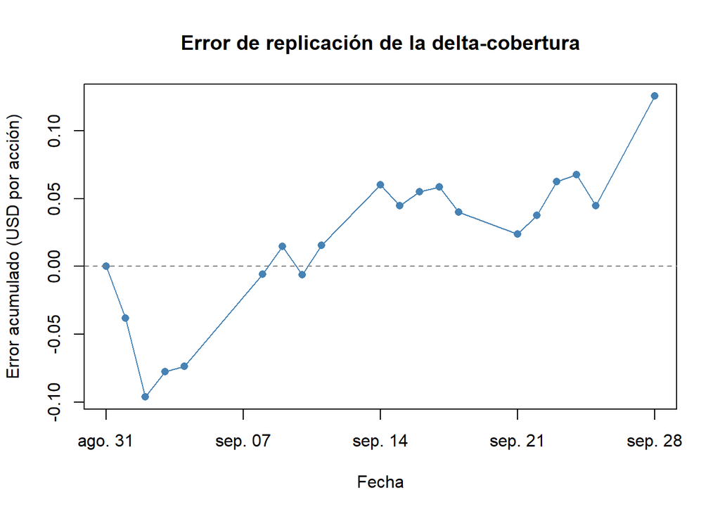

```r
plot(
  cobertura$fecha, cobertura$error_acumulado,
  type = "o", pch = 16, col = "steelblue",
  xlab = "Fecha", ylab = "Error acumulado (USD por acción)",
  main = "Error de replicación de la delta-cobertura"
)
abline(h = 0, lty = 2, col = "gray50")
```

```r
write.csv(cobertura, "NTR_delta_cobertura_20260928.csv", row.names = FALSE)
write.csv(resumen_cobertura, "NTR_resumen_cobertura_20260928.csv",
          row.names = FALSE)
```

## Capa de verificación

Se comprueba que cada rebalanceo conserve el valor de la cartera y que no requiera aportes externos. Los intereses se calculan por días calendario, incluyendo los intervalos de fin de semana. La comparación con una venta sin cobertura mide ambos resultados contra la misma prima y el mismo valor final de la call; no implica que cubrir siempre produzca un error menor en una trayectoria concreta.

```r
tolerancia <- 1e-8
indices <- 2:n_dias
valor_antes_rebalanceo <- cobertura$delta[indices - 1] *
  cobertura$close[indices] + cobertura$efectivo[indices - 1] +
  cobertura$intereses[indices] + cobertura$dividendos_modelo[indices]

chequeos_cobertura <- data.frame(
  Chequeo = c(
    "Veinte sesiones distintas y ordenadas",
    "Valores finitos",
    "Delta entre cero y exp(-q * plazo)",
    "Error inicial igual a cero",
    "Rebalanceos conservan el valor de la cartera",
    "Suma de errores incrementales igual al error final"
  ),
  Resultado = c(
    n_dias == 20 && all(diff(cobertura$fecha) > 0),
    all(is.finite(as.matrix(cobertura[, c(
      "precio_call", "delta", "efectivo", "valor_cartera", "error_acumulado"
    )]))),
    all(cobertura$delta >= 0 &
          cobertura$delta <= exp(-q_cobertura * cobertura$plazo) + tolerancia),
    abs(cobertura$error_acumulado[1]) < tolerancia,
    max(abs(valor_antes_rebalanceo - cobertura$valor_cartera[indices])) <
      tolerancia,
    abs(sum(cobertura$error_incremental) -
          cobertura$error_acumulado[n_dias]) < tolerancia
  )
)
chequeos_cobertura
```

```
##                                              Chequeo Resultado
## 1              Veinte sesiones distintas y ordenadas      TRUE
## 2                                    Valores finitos      TRUE
## 3                 Delta entre cero y exp(-q * plazo)      TRUE
## 4                         Error inicial igual a cero      TRUE
## 5       Rebalanceos conservan el valor de la cartera      TRUE
## 6 Suma de errores incrementales igual al error final      TRUE
```

```r
plazo_ventana <- as.numeric(cobertura$fecha[n_dias] - cobertura$fecha[1]) / 365
error_sin_cobertura <- prima_inicial * exp(r_cobertura * plazo_ventana) -
  cobertura$precio_call[n_dias]

comparacion_cobertura <- data.frame(
  estrategia = c("Delta con rebalanceo diario", "Prima en efectivo sin acciones"),
  resultado_final = c(cobertura$error_acumulado[n_dias], error_sin_cobertura)
)
comparacion_cobertura
```

```
##                       estrategia resultado_final
## 1    Delta con rebalanceo diario       0.1254713
## 2 Prima en efectivo sin acciones       2.9779518
```

## Qué queda pendiente

Esta es una simulación retrospectiva bajo un modelo europeo, con acciones fraccionarias, sin comisiones ni spread en las operaciones de cobertura. La prima inicial y los valores diarios de la opción son teóricos porque no se incorporó su historia de bid/ask. Por ello, el resultado no constituye un P&L observado de mercado.